# Binary Multiple Predictors

# Overview

This script fits a Bayesian multivariate model to predict probability of climbing behavior from skeletal morphology in rodents. The model uses a custom Bernoulli family to handle species with unknown locomotion (i.e., fossils or species of interest), and a joint imputation model to handle missing skeletal measurements.

Predictions are made for four focal Florida rodent species: - Ochrotomys nuttalli (golden mouse — expected to be more arboreal) - Peromyscus gossypinus (cotton mouse) - Peromyscus polionotus (oldfield mouse) - Podomys floridanus (Florida mouse)

# 1. Setup

```r
# Load cleaned data (wrangling done in Code/Data_Wrangle.Rmd)
dat <- read_csv(here("Data", "Clean_Data.csv"))
# Species present in dataset (needed to prune the phylogeny)
spp_obs <- dat$Taxon_Upham_style %>% unique()

# Color palette (one color per species, used throughout)
pal <- c('#62361B', '#f48a1a', '#e6ab02', '#66a61e', '#31c1bb',
         '#0d57ff', '#5e1ea6', '#f9581c', '#f384f8')

# Load phylogenetic tree and compute correlation matrix
# vcv.phylo() returns a variance-covariance matrix used as a prior
# for the phylogenetic random effect in brms
tr <- ape::read.nexus(here("Data", "MCC_Upham_all_mammals.nex"))
tr <- ape::keep.tip(tr, spp_obs)
A  <- ape::vcv.phylo(tr, corr = TRUE)
```

# 2. Custom Bernoulli Family for Missing Locomotion Data

The key challenge: many species in the dataset have no known locomotion category (Loc_bin = NA). We want to fit the model using species with known locomotion, but generate predictions for species without it.

The standard approach would be to drop NAs, but we also want those species’ morphology to inform the imputation submodels. The solution is a custom Stan likelihood function that contributes zero to the log-likelihood when locomotion is unknown — effectively marginalizing those observations out.

Mathematically: P(data | Loc_bin unknown) = p + (1-p) = 1, so log P = 0.

```r
# Create a placeholder response and an observation indicator:
# Loc_bin_obs = -1  means locomotion is unknown (excluded from likelihood)
# Loc_bin_obs >= 0  means locomotion is known (standard Bernoulli likelihood)
dat <- dat %>%
  mutate(
    Loc_bin_obs = ifelse(is.na(Loc_bin), -1L, as.integer(Loc_bin)),
    y_for_brms  = ifelse(is.na(Loc_bin),  0L, as.integer(Loc_bin))
  )

# Define the custom brms family
bernoulli_missing <- custom_family(
  name  = "bernoulli_missing",
  dpars = "mu",
  links = "logit",
  lb = 0, ub = 1,
  type = "int",
  vars = "vint1[n]"   # vint1 carries Loc_bin_obs into Stan
)

# Stan function: if obs is known, use standard Bernoulli; if unknown, return 0
stan_funs <- "
  real bernoulli_missing_lpmf(int y_placeholder, real mu, int y_obs) {
    if (y_obs >= 0) {
      return bernoulli_lpmf(y_obs | mu);  // known: standard likelihood
    } else {
      return 0;                            // unknown: excluded from likelihood
    }
  }
"
stanvars <- stanvar(scode = stan_funs, block = "functions")

# Required for add_epred_draws() to know how to compute expected values
# for this custom family (brms can't infer this automatically)
posterior_epred_bernoulli_missing <- function(prep) {
  mu <- brms::get_dpar(prep, "mu")
  mu
}
```

# 3. Model Specification

Predictors come from variable selection that used predictive accuracy. The top 10 accurate skeletal predictors are used, plus log body mass.

Complete measurements (no missing data): Fl, Hl, HPI, Uol Measurements with some missing data: PES, MANUS, Ppl, Ul, OLI, Rl, log_Mass

Missing measurements are handled by joint imputation submodels: each missing variable is modeled as a function of the complete skeletal measurements, with its own phylogenetic random effect. The imputed values are integrated into the main model, propagating imputation uncertainty into climbing predictions.

```r
# Main binary outcome model
bin_mod <- bf(
  y_for_brms | vint(Loc_bin_obs) ~
    Fl + Hl + HPI + Uol +                            # complete predictors
    mi(PES) + mi(MANUS) + mi(Ppl) + mi(Ul) +         # imputed predictors
    mi(OLI) + mi(Rl) + mi(log_Mass) +
    (1 | Genus_species) +                             # species random effect
    (1 | gr(Taxon_Upham_style, cov = A))              # phylogenetic random effect
) + bernoulli_missing

# Imputation submodels — one per missing variable
# Each predicts the missing measurement from the complete skeletal measurements
PES_mod   <- bf(PES   | mi() ~ Fl + Fdw + Fsw + Tpw + Hl + Hdw + Hpw + Hsw + Uol + Mtl + (1|Genus_species) + (1|gr(Taxon_Upham_style, cov = A))) + gaussian()
MANUS_mod <- bf(MANUS | mi() ~ Fl + Fdw + Fsw + Tpw + Hl + Hdw + Hpw + Hsw + Uol + Mtl + (1|Genus_species) + (1|gr(Taxon_Upham_style, cov = A))) + gaussian()
Ppl_mod   <- bf(Ppl   | mi() ~ Fl + Fdw + Fsw + Tpw + Hl + Hdw + Hpw + Hsw + Uol + Mtl + (1|Genus_species) + (1|gr(Taxon_Upham_style, cov = A))) + gaussian()
Ul_mod    <- bf(Ul    | mi() ~ Fl + Fdw + Fsw + Tpw + Hl + Hdw + Hpw + Hsw + Uol + Mtl + (1|Genus_species) + (1|gr(Taxon_Upham_style, cov = A))) + gaussian()
OLI_mod   <- bf(OLI   | mi() ~ Fl + Fdw + Fsw + Tpw + Hl + Hdw + Hpw + Hsw + Uol + Mtl + (1|Genus_species) + (1|gr(Taxon_Upham_style, cov = A))) + gaussian()
Rl_mod    <- bf(Rl    | mi() ~ Fl + Fdw + Fsw + Tpw + Hl + Hdw + Hpw + Hsw + Uol + Mtl + (1|Genus_species) + (1|gr(Taxon_Upham_style, cov = A))) + gaussian()
mass_mod  <- bf(log_Mass | mi() ~ Fl + Fdw + Fsw + Tpw + Hl + Hdw + Hpw + Hsw + Uol + Mtl + (1|Genus_species) + (1|gr(Taxon_Upham_style, cov = A))) + gaussian()

# Combine all submodels; set_rescor(FALSE) because residual correlations
# between responses are not meaningful here
m_form <- bin_mod + PES_mod + MANUS_mod + Ppl_mod + Ul_mod +
          OLI_mod + Rl_mod + mass_mod + set_rescor(FALSE)

# Priors — weakly informative
# coef == "" targets class-level priors only (not individual coefficients)
pri <- get_prior(m_form, data = dat, data2 = list(A = A)) %>%
  mutate(prior = case_when(
    class == "b" & coef == ""                          ~ "normal(0, 2)",
    class == "sd" & coef == "" & resp == "yforbrms"    ~ "normal(0, 0.3)",
    class == "sd" & coef == "" & resp != "yforbrms"    ~ "normal(0, 1)",
    class == "Intercept"                               ~ "normal(0, 2)",
    class == "sigma"                                   ~ "normal(0, 0.5)",
    TRUE ~ prior
  ))
```

# 4. Fit and Save Model

```r
multmod <- brm(
  m_form,
  data     = dat,
  data2    = list(A = A),
  prior    = pri,
  cores    = 4,
  seed     = 145,
  refresh  = 0,
  silent   = 2,
  control  = list(max_treedepth = 15),
  stanvars = stanvars
)

multmod %>% write_rds(here("Data", "B_mod_multi.Rds"))
```

# 5. Prepare Prediction Data

```r
# Focal species for prediction
mice <- c("Podomys_floridanus", "Ochrotomys_nuttalli",
          "Peromyscus_gossypinus", "Peromyscus_polionotus")

# Filter to focal species and set locomotion as unknown for all specimens
# (y_for_brms = 0 and Loc_bin_obs = -1 tells the model to exclude these
# from the likelihood and generate predictions only)
model_dat <- dat %>%
  filter(Genus_species %in% mice) %>%
  mutate(
    y_for_brms  = 0L,
    Loc_bin_obs = -1L
  )
```

# 6. Full Predictions (individual specimens)

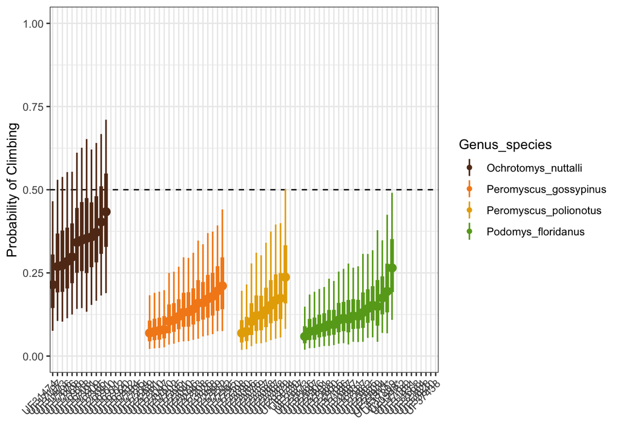

```r
# Predictions for each individual specimen using the full model
# (both species and phylogenetic random effects included)
pred_df_ext_full <- multmod %>%
  add_epred_draws(
    newdata          = model_dat,
    resp             = "yforbrms",       # response name (brms strips underscores)
    value            = "Prob_of_Climbing",
    allow_new_levels = TRUE,
    re_formula       = NULL              # include all random effects
  ) %>%
  as.data.frame() %>%
  select(Genus_species, Prob_of_Climbing, catalog)

# Plot individual specimens sorted by species and mean prediction
pred_df_ext_full %>%
  group_by(catalog, Genus_species) %>%
  mutate(mean_prob = mean(Prob_of_Climbing, na.rm = TRUE)) %>%
  ungroup() %>%
  mutate(
    catalog = reorder(catalog, mean_prob),
    catalog = reorder(catalog, as.numeric(factor(Genus_species)))
  ) %>%
  ggplot(aes(y = Prob_of_Climbing, x = catalog, color = Genus_species)) +
  geom_hline(yintercept = 0.5, linetype = 2, linewidth = 0.5) +
  stat_pointinterval(.width = c(0.5, 0.89)) +
  ylim(0, 1) +
  labs(x = "", y = "Probability of Climbing") +
  scale_color_manual(values = pal) +
  theme_bw() +
  theme(axis.text.x = element_text(angle = 45, hjust = 1))
```

# 7. Proper Imputation-Aware Predictions

## Why this is needed

brms’s mi() imputation works by estimating posterior distributions for missing values during model fitting (stored as Ymi_ parameters in the Stan output). However, when predicting for new data, brms cannot impute new missing values — it only imputed the specific NA slots it saw during training.

The solution: extract the posterior imputed values (Ymi_) from the fitted model and inject them draw-by-draw into the prediction newdata. This properly propagates imputation uncertainty into the climbing predictions rather than collapsing missing values to a point estimate (e.g., species median).

This matters especially for PES, which has a large coefficient (~1.56 on the logit scale) and imputation intervals up to 2.5 z-score units wide.

```r
# Identify which rows in dat correspond to focal species
focal_rows <- which(dat$Genus_species %in% mice)

# Extract posterior imputed values for all mi() variables
ymi_draws <- as_draws_df(multmod) %>%
  select(.draw, starts_with("Ymi_"))

# Parse the Ymi_ column names to get variable name and original row index
# The index in e.g. Ymi_PES[62] refers to row 62 of dat
ymi_index_df <- tibble(col = names(ymi_draws)[-1]) %>%
  mutate(
    variable = str_extract(col, "(?<=Ymi_)[A-Za-z]+"),
    row_idx  = as.integer(str_extract(col, "(?<=\\[)\\d+(?=\\])"))
  ) %>%
  filter(row_idx %in% focal_rows) %>%
  left_join(
    dat %>% mutate(row_idx = row_number()) %>% select(row_idx, catalog, Genus_species),
    by = "row_idx"
  )

# Pivot to long format for easy per-draw filtering
ymi_long <- ymi_draws %>%
  pivot_longer(-.draw, names_to = "col", values_to = "imputed") %>%
  inner_join(ymi_index_df %>% select(col, variable, row_idx, catalog), by = "col") %>%
  select(.draw, variable, row_idx, catalog, imputed)

# mi() variables that need draw-by-draw imputation
mi_vars <- c("PES", "MANUS", "Ppl", "Ul", "OLI", "Rl", "log_Mass")

# Add row indices to model_dat for joining with Ymi_ draws
model_dat_indexed <- model_dat %>%
  mutate(row_idx = which(dat$Genus_species %in% mice))

# Empty tibble to ensure all _imp columns always exist after pivot_wider
# (avoids errors when a variable has no missing values for a given draw)
empty_imp <- tibble(
  row_idx      = integer(),
  PES_imp      = double(), MANUS_imp    = double(), Ppl_imp      = double(),
  Ul_imp       = double(), OLI_imp      = double(), Rl_imp       = double(),
  log_Mass_imp = double()
)
```

warning, this takes a long time, maybe don’t try it on your computer.

```r
# Run predictions draw-by-draw, filling in imputed values for each draw
# Uses parallel processing (furrr) for speed and chunked saving for safety
# ~5 minutes with 8 workers and 1000 thinned draws

tictoc::tic()
plan(multisession, workers = 8)

thin_draws <- seq(1, 4000, by = 4)  # thin to 1000 draws (every 4th)
chunk_size <- 250
chunks     <- split(thin_draws, ceiling(seq_along(thin_draws) / chunk_size))

for (chunk_i in seq_along(chunks)) {
  chunk_draws <- chunks[[chunk_i]]
  message(glue("Starting chunk {chunk_i} of {length(chunks)}"))

  chunk_results <- future_map(chunk_draws, ~{
    d <- .x

    # Get imputed values for this draw, ensuring all _imp columns exist
    imputed_d <- ymi_long %>%
      filter(.draw == d) %>%
      select(row_idx, variable, imputed) %>%
      pivot_wider(names_from = variable, values_from = imputed) %>%
      bind_rows(empty_imp)

    # Fill in missing mi() variables with this draw's imputed values
    # coalesce() keeps observed values and fills NAs with imputed values
    newdata_d <- model_dat_indexed %>%
      left_join(imputed_d, by = "row_idx", suffix = c("", "_imp")) %>%
      mutate(
        PES      = coalesce(PES,      PES_imp),
        MANUS    = coalesce(MANUS,    MANUS_imp),
        Ppl      = coalesce(Ppl,      Ppl_imp),
        Ul       = coalesce(Ul,       Ul_imp),
        OLI      = coalesce(OLI,      OLI_imp),
        Rl       = coalesce(Rl,       Rl_imp),
        log_Mass = coalesce(log_Mass, log_Mass_imp)
      ) %>%
      select(-ends_with("_imp"), -row_idx)

    # Generate prediction for this single draw, then tag with draw number
    # (draw_ids reindexes internally so we tag manually with mutate)
    multmod %>%
      add_epred_draws(
        newdata          = newdata_d,
        resp             = "yforbrms",
        value            = "Prob_of_Climbing",
        allow_new_levels = TRUE,
        re_formula       = NULL,
        draw_ids         = d
      ) %>%
      as.data.frame() %>%
      select(Genus_species, catalog, Prob_of_Climbing) %>%
      mutate(.draw = d)

  }, .options = furrr_options(
    seed    = TRUE,
    globals = c("ymi_long", "model_dat_indexed", "empty_imp", "multmod",
                "posterior_epred_bernoulli_missing"),
    packages = c("dplyr", "tidyr", "brms", "tidybayes")
  ))

  saveRDS(chunk_results, here("Data", glue("pred_chunk_{chunk_i}.rds")))
  message(glue("Chunk {chunk_i} saved"))
}
```

```
Starting chunk 1 of 4
```

```
Chunk 1 saved
```

```
Starting chunk 2 of 4
```

```
Chunk 2 saved
```

```
Starting chunk 3 of 4
```

```
Chunk 3 saved
```

```
Starting chunk 4 of 4
```

```
Chunk 4 saved
```

```r
plan(sequential)
tictoc::toc()
```

```
248.753 sec elapsed
```

```r
# Reassemble all chunks into a single dataframe
pred_proper <- map(seq_along(chunks), ~{
  readRDS(here("Data", glue("pred_chunk_{.x}.rds")))
}) %>%
  flatten() %>%
  bind_rows()
```

# 8. Plots

## Individual specimen predictions

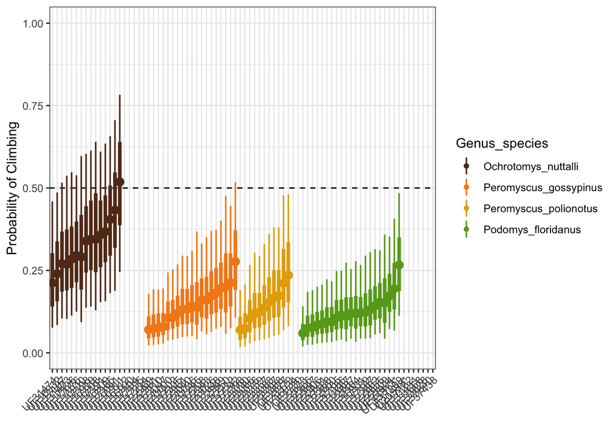

```r
pred_proper %>%
  group_by(catalog, Genus_species) %>%
  mutate(mean_prob = mean(Prob_of_Climbing, na.rm = TRUE)) %>%
  ungroup() %>%
  mutate(
    catalog = reorder(catalog, mean_prob),
    catalog = reorder(catalog, as.numeric(factor(Genus_species)))
  ) %>%
  ggplot(aes(y = Prob_of_Climbing, x = catalog, color = Genus_species)) +
  geom_hline(yintercept = 0.5, linetype = 2, linewidth = 0.5) +
  stat_pointinterval(.width = c(0.5, 0.89)) +
  ylim(0, 1) +
  labs(x = "", y = "Probability of Climbing") +
  scale_color_manual(values = pal) +
  theme_bw() +
  theme(axis.text.x = element_text(angle = 45, hjust = 1))
```

## Species-level predictions (averaged over individuals)

Averaging is done over posterior draws before summarizing, not over summaries. This correctly propagates individual-level uncertainty into the species estimate.

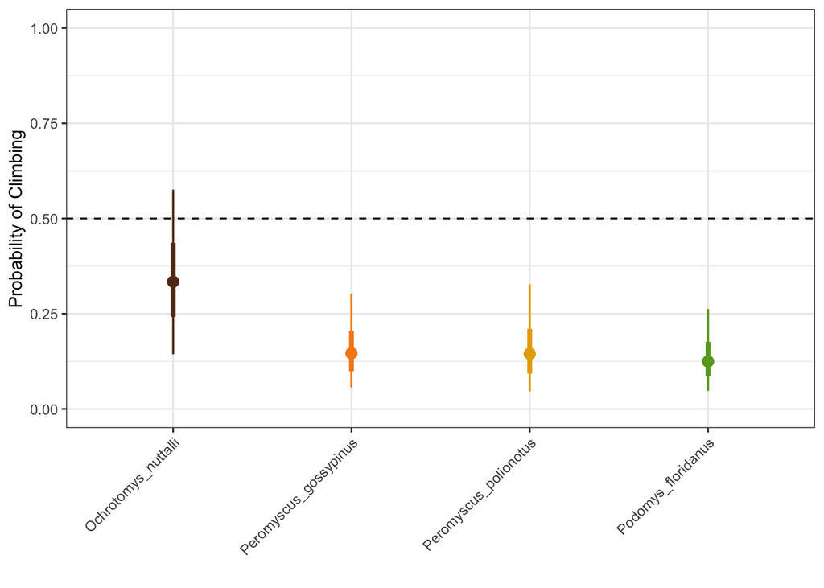

```r
pred_proper_species <- pred_proper %>%
  group_by(Genus_species, .draw) %>%
  summarise(Prob_of_Climbing = mean(Prob_of_Climbing, na.rm = TRUE), .groups = "drop")

pred_proper_species %>%
  ggplot(aes(y = Prob_of_Climbing, x = Genus_species, color = Genus_species)) +
  geom_hline(yintercept = 0.5, linetype = 2, linewidth = 0.5) +
  stat_pointinterval(.width = c(0.5, 0.89)) +
  ylim(0, 1) +
  labs(x = "", y = "Probability of Climbing") +
  scale_color_manual(values = pal) +
  theme_bw() +
  theme(
    axis.text.x = element_text(angle = 45, hjust = 1),
    legend.position = "none"
  )
```

## Pairwise contrasts between species

Contrasts are computed directly from posterior draws (pivot wide, subtract). This gives a proper posterior distribution for the difference, not just a difference of point estimates.

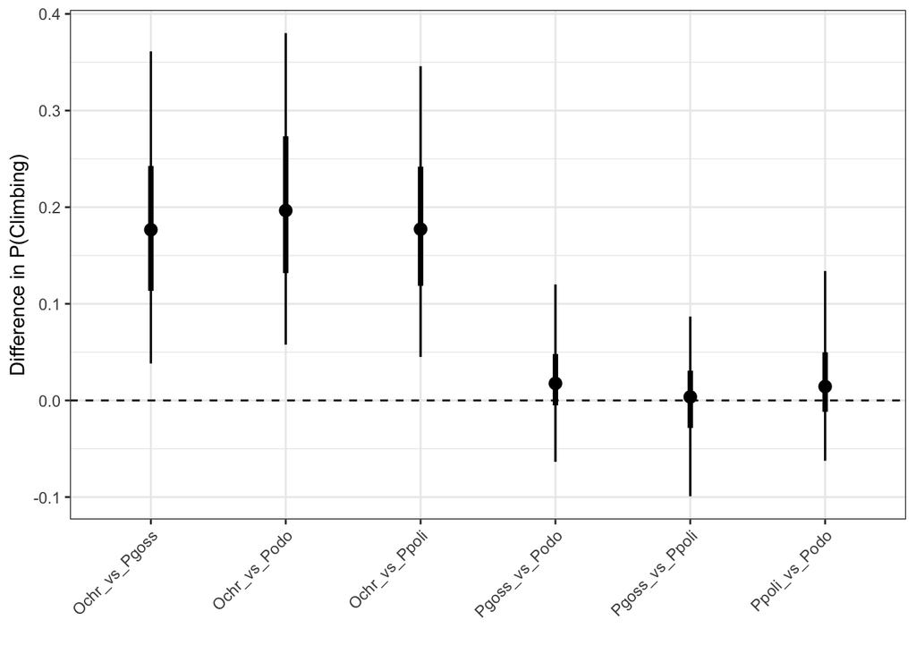

```r
pred_proper_species %>%
  pivot_wider(names_from = Genus_species, values_from = Prob_of_Climbing) %>%
  mutate(
    Ochr_vs_Pgoss  = Ochrotomys_nuttalli - Peromyscus_gossypinus,
    Ochr_vs_Ppoli  = Ochrotomys_nuttalli - Peromyscus_polionotus,
    Ochr_vs_Podo   = Ochrotomys_nuttalli - Podomys_floridanus,
    Pgoss_vs_Ppoli = Peromyscus_gossypinus - Peromyscus_polionotus,
    Pgoss_vs_Podo  = Peromyscus_gossypinus - Podomys_floridanus,
    Ppoli_vs_Podo  = Peromyscus_polionotus - Podomys_floridanus
  ) %>%
  select(.draw, Ochr_vs_Pgoss:Ppoli_vs_Podo) %>%
  pivot_longer(-.draw, names_to = "contrast", values_to = "difference") %>%
  ggplot(aes(y = difference, x = contrast)) +
  geom_hline(yintercept = 0, linetype = 2, linewidth = 0.5) +
  stat_pointinterval(.width = c(0.5, 0.89)) +
  labs(x = "", y = "Difference in P(Climbing)") +
  theme_bw() +
  theme(axis.text.x = element_text(angle = 45, hjust = 1))
```

```r
ggsave(here("Plots", "Bin_Multiple_Reg_Plots.pdf"), height = 8, width = 13)
```